# Notebook report

## Report for Simulation Video #5

I used the state file from video #4 as the starting point to continue working on Example 3 (see Questions.pdf). Since the ifelse and pmax approaches generate the same results, I will only use `profit1` in this report.

Rather than manually changing the values of `q` in the *Simulate* tab to determine the optimal value, we can use the *Repeat* tab to change the values of `q` for us in an iterative fasion.

I selected `demand` as the variable to re-simulate and `q` and `profit` as the output variables. Since I want to know the expected value of profit for each order quantity level across 1,000 simulations, I selected `repeat` in the Group by box and the `mean` function. I specified the order quantity `q` to vary from 4 cars to 11 cars in increments of 1.

I set the random seed as 1234, and leave the `# of reps` blank because I have already specified the number of required repetitions by specifying min, max, and step. The repeat data will be saved in the `repdat_car` dataset.

```r
repdat_car <- repeater(
  simdat_car,
  vars = "demand",
  grid = "q 4 11 1",
  sum_vars = c("q", "profit1"),
  byvar = ".rep",
  fun = "mean",
  seed = 1234
)
summary(repdat_car, dec = 4)
```

```
Repeated simulation
Simulations   : 1,000
Repetitions   : 12
Re-simulated  : demand
Group by      : Simulation
Function      : mean
Random  seed  : 1234
Simulated data: simdat_car
Repeat data   : repdat_car

Variables:
     variable n_obs        mean         sd         min         p25      median         p75         max
 profit1_mean     8 31,356.5000 2,654.2644 26,336.0000 30,239.5000 31,622.5000 33,687.5000 34,053.0000
 q_mean           8      7.5000     2.4495      4.0000      5.7500      7.5000      9.2500     11.0000
```

```r
register("repdat_car")
```

After clicking the `Repeat simulation` button I can see the profit for each order quantity in the *Data > View* tab. By sorting the data by `profit1_mean` in descending order, I see that the optimal value of q (i.e., `q_mean`) is 7 cars. I can also verify the result by creating a line plot using `profit1_mean` as the y-variable and `q_mean` as the x-variable.

```r
## filter and sort the dataset
repdat_car %>%
  arrange(desc(profit1_mean)) %>%
  select(.rep:profit1_mean) %>%
  dtab(dec = 2, nr = 100) %>% render()
```

| .rep | q_mean | profit1_mean |
| --- | --- | --- |
| 7 | 7 | 34053 |
| 6 | 6 | 33758 |
| 8 | 8 | 33664 |
| 5 | 5 | 32080 |
| 9 | 9 | 31165 |
| 4 | 4 | 30581 |
| 10 | 10 | 29215 |
| 11 | 11 | 26336 |

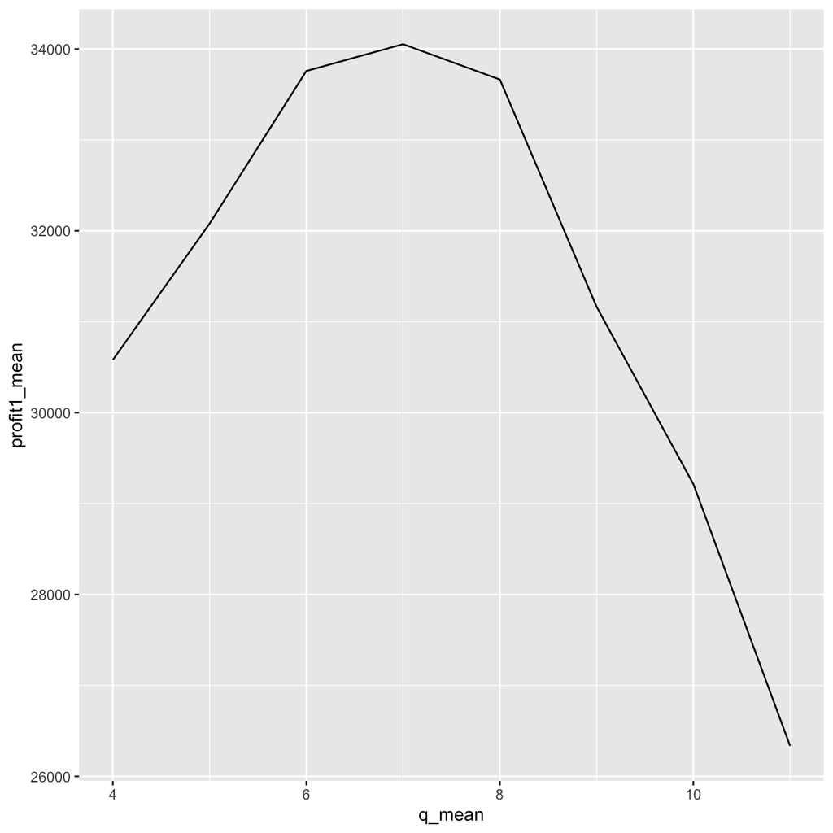

```r
visualize(
  repdat_car,
  xvar = "q_mean",
  yvar = "profit1_mean",
  type = "line",
  custom = FALSE
)
```

There is a shortcut to find the optimal value of order quantity. Add `opt_q = find_max(profit1_mean, q_mean)` to formula input box in the repeat tab. The `find_max` function will find the value of `q_mean` that maximizes `profit1_mean`. The result shows that the car dealer should order 7 cars for next year to maximize her profit.

```r
repdat_car1 <- repeater(
  simdat_car,
  vars = "demand",
  grid = "q 4 11 1",
  sum_vars = c("q", "profit1"),
  byvar = ".rep",
  fun = "mean",
  form = "opt_q = find_max(profit1_mean, q_mean)",
  seed = 1234
)
summary(repdat_car1, dec = 4)
```

```
Repeated simulation
Simulations   : 1,000
Repetitions   : 12
Re-simulated  : demand
Group by      : Simulation
Function      : mean
Random  seed  : 1234
Simulated data: simdat_car
Repeat data   : repdat_car1
Formulas      :
    opt_q = find_max(profit1_mean, q_mean)

Constants:
  opt_q
 7.0000

Variables:
     variable n_obs        mean         sd         min         p25      median         p75         max
 profit1_mean     8 31,356.5000 2,654.2644 26,336.0000 30,239.5000 31,622.5000 33,687.5000 34,053.0000
 q_mean           8      7.5000     2.4495      4.0000      5.7500      7.5000      9.2500     11.0000
```

```r
register("repdat_car1")
```